# Traffic_Sign_Classifier_Project

The purpose of this project is to create an end-to-end process of classifying [German traffic sign images](http://benchmark.ini.rub.de/?section=gtsrb&subsection=dataset). The complete process includes:

1. Preparation for data
2. Exploratory data analysis
3. Data processing and augmentation
4. Building a model archtecture for classification
5. Deciding a loss function, metric(s), and other hyperparameters such as learning rate
6. Training the model
7. Analysing the results from the trained model on a new dataset

To undertake this project, I particularly focused on **enhancing performance by creating a model architecture with tensorflow based on Resnet blocks (https://arxiv.org/abs/1512.03385) and Squeeze and Excitation blocks (https://arxiv.org/abs/1709.01507)**.

In addition, I incorporated mitigation measures for overfitting issues through **adopting data augmentation**, such as rotation, horizontal flip, gaussian blur and adding noise, **incorporating cross validation sets** as well as **placing batch normalisation layers** in the model architecture.

Prior to a start, I will import packages and libraries required to undertake this project.

### Import packages

```python
%matplotlib inline

from PIL import Image
import matplotlib.pyplot as plt
import os
import cv2
import random
import pickle
from scipy import ndarray
import numpy as np
import pandas as pd
import skimage as sk
from skimage import transform
from skimage import util
from sklearn.utils import shuffle
from sklearn.model_selection import StratifiedKFold
import tensorflow as tf
import tensorflow.contrib as contrib
from tensorflow.contrib.layers import flatten
```

### Structure of the project

This project is strucutured with the four large segments as follow:

- Data - this section includes preparataion of importing and formatting data, exploratory data analysis, and data processing and augmentation prior to training.
- Model architecture - this segment focuses on building an tailored arthitecture for the project. Two convolutional blocks, Resnet blocks and Squeeze and Excitation blocks (SE blocks), are built in the architecture.
- Training - this segment provides explanations and codes around loss function, metrics and training hyperparameters and how they are built in the TrainingPipeline class.
- Result Analysis - this section outlines the results of validation sets and new test dataset. In addition, testing on newly-downloaded datasets is undertaken in this section.

## Data

Before starting anything, I would like to random seed so that we could have a reproducible result from this notebook.

```python
np.random.seed(42)
```

Then, I will import the dataset, explore the data, and finally process and augment the data for training.

### Set up for data

To import the datasets composed of train, validation and test sets, I write the define_dataset function to import and do an integrity check.

```python
def define_dataset(path_to_data):
    #define filename for each set
    training_file = os.path.join(path_to_data, "train.p")
    validation_file= os.path.join(path_to_data, "valid.p")
    testing_file = os.path.join(path_to_data, "test.p")

    with open(training_file, mode='rb') as f:
        train = pickle.load(f)
    with open(validation_file, mode='rb') as f:
        valid = pickle.load(f)
    with open(testing_file, mode='rb') as f:
        test = pickle.load(f)

    X_train, y_train = train['features'], train['labels']
    X_valid, y_valid = valid['features'], valid['labels']
    X_test, y_test = test['features'], test['labels']

    #integrity check
    assert len(X_train)==len(y_train)
    assert len(X_valid)==len(y_valid)
    assert len(X_test)==len(y_test)
    return X_train, y_train, X_valid, y_valid, X_test, y_test
```

The path to data in my local drive is under '/data'. Six different datasets are imported below.

```python
path_to_data = "data/"
X_train, y_train, X_valid, y_valid, X_test, y_test = define_dataset(path_to_data)
```

However, my intention is to use cross-validation datasets so I combine train and validation datasets into one for both features and labels.

```python
X_train_valid = np.concatenate((X_train, X_valid), axis=0)
```

When combined together, the number of training and validation data consists 39,209 examples.

```python
n_train_valid = len(X_train_valid)
n_train_valid
```

```
39209
```

```python
y_train_valid = np.concatenate((y_train, y_valid), axis=0)
```

```python
len(y_train_valid)
```

```
39209
```

The number of test data is 12,630.

```python
n_test = len(X_test)
n_test
```

```
12630
```

The shape of images are 32x32x3 (Height, Width, Colour channel).

```python
image_shape = X_train_valid.shape[1:]
image_shape
```

```
(32, 32, 3)
```

The names of labels are then imported from "signnames.csv".

```python
class_file = "signnames.csv"
```

```python
class_df = pd.read_csv(os.path.join(path_to_data, class_file))
```

The names of the signs are quite clear (e.g. Speed limit, No entry, Roundabout mandatory)

```python
class_df
```

|  | ClassId | SignName |
| --- | --- | --- |
| 0 | 0 | Speed limit (20km/h) |
| 1 | 1 | Speed limit (30km/h) |
| 2 | 2 | Speed limit (50km/h) |
| 3 | 3 | Speed limit (60km/h) |
| 4 | 4 | Speed limit (70km/h) |
| 5 | 5 | Speed limit (80km/h) |
| 6 | 6 | End of speed limit (80km/h) |
| 7 | 7 | Speed limit (100km/h) |
| 8 | 8 | Speed limit (120km/h) |
| 9 | 9 | No passing |
| 10 | 10 | No passing for vehicles over 3.5 metric tons |
| 11 | 11 | Right-of-way at the next intersection |
| 12 | 12 | Priority road |
| 13 | 13 | Yield |
| 14 | 14 | Stop |
| 15 | 15 | No vehicles |
| 16 | 16 | Vehicles over 3.5 metric tons prohibited |
| 17 | 17 | No entry |
| 18 | 18 | General caution |
| 19 | 19 | Dangerous curve to the left |
| 20 | 20 | Dangerous curve to the right |
| 21 | 21 | Double curve |
| 22 | 22 | Bumpy road |
| 23 | 23 | Slippery road |
| 24 | 24 | Road narrows on the right |
| 25 | 25 | Road work |
| 26 | 26 | Traffic signals |
| 27 | 27 | Pedestrians |
| 28 | 28 | Children crossing |
| 29 | 29 | Bicycles crossing |
| 30 | 30 | Beware of ice/snow |
| 31 | 31 | Wild animals crossing |
| 32 | 32 | End of all speed and passing limits |
| 33 | 33 | Turn right ahead |
| 34 | 34 | Turn left ahead |
| 35 | 35 | Ahead only |
| 36 | 36 | Go straight or right |
| 37 | 37 | Go straight or left |
| 38 | 38 | Keep right |
| 39 | 39 | Keep left |
| 40 | 40 | Roundabout mandatory |
| 41 | 41 | End of no passing |
| 42 | 42 | End of no passing by vehicles over 3.5 metric ... |

There are 43 classes/labels avaliable. This 'n_classes' variable will be used throughout the project.

```python
n_classes = class_df['SignName'].nunique()
n_classes
```

```
43
```

### Exploratory Data Analysis

After importing the dataset, it is time to explore what kinds of data are available and what characteristics they have. I will start with the description and distribution of the dataset.

#### Description and distribution of the dataset

I will start with the label dataset. Looking at the first five row and last five row of the data below, the dataset is arranged/grouped by its label. Therefore, shuffling the dataset is required before training; otherwise, with the batch processing class by class will be learnt, which is not desirable when testing with a validation set.

```python
y_train_df = pd.DataFrame(y_train_valid, columns=['labels'])
```

```python
y_train_df.head()
```

|  | labels |
| --- | --- |
| 0 | 41 |
| 1 | 41 |
| 2 | 41 |
| 3 | 41 |
| 4 | 41 |

```python
y_train_df.tail()
```

|  | labels |
| --- | --- |
| 39204 | 25 |
| 39205 | 25 |
| 39206 | 25 |
| 39207 | 25 |
| 39208 | 25 |

I would like to understand how the examples are distributed - are we dealing with a balanced dataset?

```python
y_train_df.groupby('labels').size()
```

```
labels
0      210
1     2220
2     2250
3     1410
4     1980
5     1860
6      420
7     1440
8     1410
9     1470
10    2010
11    1320
12    2100
13    2160
```

[output cut: 30 more lines]

More completely, for each label, the starting index and the number of examples are listed below.

```python
class_label, class_start, count = np.unique(y_train_valid, return_index = True, return_counts = True)
for info in zip(class_label, class_start, count):
    print(info)
```

```
(0, 9960, 210)
(1, 2220, 2220)
(2, 31439, 2250)
(3, 5370, 1410)
(4, 6810, 1980)
(5, 12360, 1860)
(6, 21450, 420)
(7, 23730, 1440)
(8, 15870, 1410)
(9, 11040, 1470)
(10, 17130, 2010)
(11, 8580, 1320)
(12, 27329, 2100)
(13, 21810, 2160)
(14, 29219, 780)
(15, 29909, 630)
(16, 5010, 420)
(17, 30449, 1110)
(18, 20370, 1200)
(19, 6630, 210)
(20, 25950, 360)
(21, 25680, 330)
(22, 4500, 390)
(23, 1770, 510)
(24, 10800, 270)
(25, 33449, 1500)
(26, 1230, 600)
(27, 10350, 240)
(28, 26849, 540)
(29, 10560, 270)
(30, 25020, 450)
(31, 210, 780)
(32, 10140, 240)
(33, 26250, 689)
(34, 20010, 420)
(35, 18930, 1200)
(36, 900, 390)
(37, 4830, 210)
(38, 14010, 2070)
(39, 25410, 300)
(40, 4200, 360)
(41, 0, 240)
(42, 9750, 240)
```

The maximum examples are for label 2, "Speed limit (50km/h)", which has 2250 images and labels are available. The minimum examples, 210 images, are for lable 0, 19 and 37, "Speed limit (20km/h)", "Dangerous curve to the left" and "Go straight or left".

As it can be seen above, the dataset seems to be heavily imbalanced ranged from 210 to 2250 images per label. This imabalance is visualised below.

```python
def plot_class(x, y, x_label='Class', y_lable='Number of training images'):
    plt.bar(np.arange(x), y, align='center', color='magenta')
    plt.xlabel('Classes')
    plt.ylabel('Number of training images')
    plt.xlim([-2, n_classes+1])
    plt.show()
```

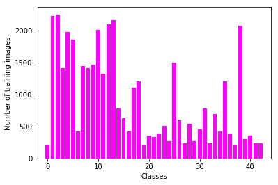

```python
plot_class(n_classes, y_train_df.groupby('labels').size())
```

#### Data visualisation

To visualise the data, I am using the plot_samples_per_label method to display a sample of images per label.

```python
def plot_samples_per_label():
    for i in range(len(class_df)):
        print(f"Class: {class_df['ClassId'].iloc[i]}, {class_df['SignName'].iloc[i]}")
        f = plt.figure(figsize = (15, 1))
        plt.subplots_adjust(left=0., right=1, top=0.9, bottom=0.)
        random_samples = random.sample(range(class_start[i], class_start[i] + count[i]), 10)
        for j in range(10):
            ax = f.add_subplot(1, 10, j+1, xticks=[], yticks=[])
            ax.imshow(X_train_valid[random_samples[j]])
        plt.show()
```

```
Class: 0, Speed limit (20km/h)
```

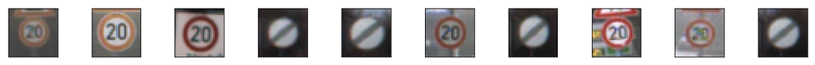

```
Class: 1, Speed limit (30km/h)
```

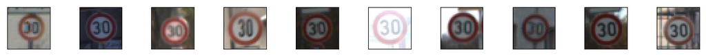

```
Class: 2, Speed limit (50km/h)
```

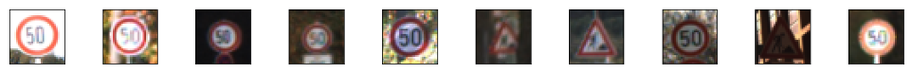

```
Class: 3, Speed limit (60km/h)
```

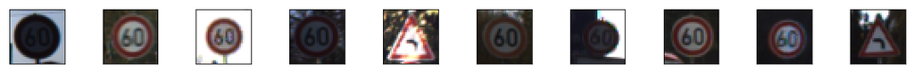

```
Class: 4, Speed limit (70km/h)
```

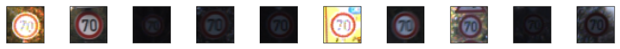

```
Class: 5, Speed limit (80km/h)
```

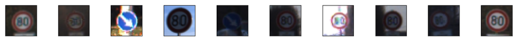

```
Class: 6, End of speed limit (80km/h)
```

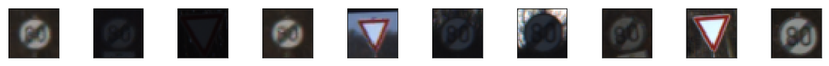

```
Class: 7, Speed limit (100km/h)
```

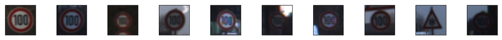

```
Class: 8, Speed limit (120km/h)
```

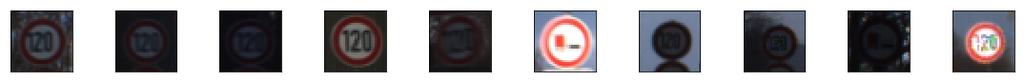

```
Class: 9, No passing
```

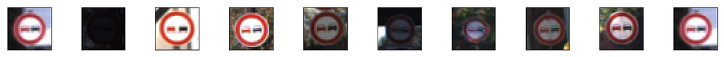

```
Class: 10, No passing for vehicles over 3.5 metric tons
```

[figure not shown]

```
Class: 11, Right-of-way at the next intersection
```

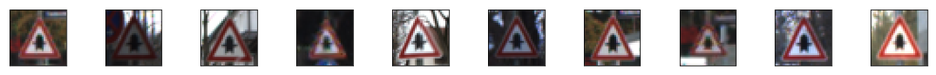

```
Class: 12, Priority road
```

[31 more figures not shown]

```python
plot_samples_per_label()
```

Some images seem to have really bad quality. For instance, the second left example from Class 26, Traffic signals is not noticible because of its darkness.

Also, some labels for the examples are not correct. For example, the sixth example from Class 8, Speed limit is labelled incorrectly - this image seems to belong to Class 10, No passing for vehicles over 3.5 metric tones. The second last example from Class 14, Stop seems to belong to Class 15, No vehicles.

Because the images include different levels of brightness, I will focus on data augmentation methods that are more related to phyical transforms such as rotation and horizontal flip. Also, adding noise and blur are adopted for data augmentation.

### Data processing

```python
class Dataset():
    def __init__(self, X, y, k):
        self.X = X
        self.y = y
        self.k_fold = k
        self.X_train_set = []
        self.y_train_set = []
        self.X_valid_set = []
        self.y_valid_set = []

    def cross_validation(self):
        skf = StratifiedKFold(n_splits=self.k_fold, random_state=True, shuffle=True)
        skf.get_n_splits(self.X, self.y)
        for train_index, valid_index in skf.split(self.X, self.y):
            X_train, X_valid = self.X[train_index], self.X[valid_index]
            y_train, y_valid = self.y[train_index], self.y[valid_index]
            assert len(X_train)==len(y_train)
            assert len(X_valid)==len(y_valid)
            self.X_train_set.append(X_train)
            self.y_train_set.append(y_train)
            self.X_valid_set.append(X_valid)
            self.y_valid_set.append(y_valid)
        return  self.X_train_set, self.X_valid_set, self.y_train_set, self.y_valid_set
```

```python
ds = Dataset(X_train_valid, y_train_valid, 5)
```

```python
X_train_set, X_valid_set, y_train_set, y_valid_set = ds.cross_validation()
```

```python
#5 cross validation set
len(X_train_set), len(X_valid_set)
```

```
(5, 5)
```

Then, I normalise the dataset and prepare train and validation sets before training.

```python
def normalise(X):
    epsilon = 1e-06
    X_trans = X/255 + epsilon
    return X_trans
```

```python
X_train = []
for i in range(len(X_train_set)):
    X_train_trans = normalise(X_train_set[i])
    X_train.append(X_train_trans)
```

```python
X_valid = []
for i in range(len(X_valid_set)):
    X_valid_trans = normalise(X_valid_set[i])
    X_valid.append(X_valid_trans)
```

```python
X_test = normalise(X_test)
```

```python
#integrity check
len(X_train)==len(X_valid), len(X_train)
```

```
(True, 5)
```

```python
len(X_train[0]), len(X_valid[0])
```

```
(31367, 7842)
```

### Data Augmentation

As discussed before, four data agumentation methods are used: rotation, horizontal flip, adding noise and blurring images. To display the effect of each method, I will use the display_image method to provide the original image on the left and the transformed image on the right.

Rotation

```python
def rotate(X, degree):
    random_degree = random.uniform(-1*degree, degree)
    image = sk.transform.rotate(X, random_degree)
    return image
```

Noise

```python
def add_noise(X):
    image = sk.util.random_noise(X, mode='gaussian')
    return image
```

Horizontal flip

```python
def flip_horizontal(X):
    image = X[:, ::-1]
    return image
```

Blur

```python
def blur(X):
    random_int = random.randrange(4)
    image = sk.filters.gaussian(X, random_int, multichannel=True, mode='reflect')
    return image
```

```python
aug = ['Rotation', 'Noise', 'Horizontal flip', 'Blur']
def display_image():
    #original
    f = plt.figure(figsize = (12, 1))
    plt.subplots_adjust(left=0., right=1, top=0.9, bottom=0.)
    random_sample = random.sample(range(0, len(X_train_set[0])), 10)
    print("Original sample of images: ")
    for i in range(10):
        ax = f.add_subplot(1, 10, i+1, xticks=[], yticks=[])
        ax.imshow(X_train_set[0][random_sample[i]])
    plt.show()
    #rotation
    f = plt.figure(figsize = (12, 1))
    plt.subplots_adjust(left=0., right=1, top=0.9, bottom=0.)
    print(f"{aug[0]} sample of images: ")
    for i in range(10):
        ax = f.add_subplot(1, 10, i+1, xticks=[], yticks=[])
        trans_img = rotate(X_train_set[0][random_sample[i]], 50)
        ax.imshow(trans_img)
    plt.show()
    #Noise
    f = plt.figure(figsize = (12, 1))
    plt.subplots_adjust(left=0., right=1, top=0.9, bottom=0.)
    print(f"{aug[1]} sample of images: ")
    for i in range(10):
        ax = f.add_subplot(1, 10, i+1, xticks=[], yticks=[])
        trans_img = add_noise(X_train_set[0][random_sample[i]])
        ax.imshow(trans_img)
    plt.show()
    #Horizontal flip
    f = plt.figure(figsize = (12, 1))
    plt.subplots_adjust(left=0., right=1, top=0.9, bottom=0.)
    print(f"{aug[2]} sample of images: ")
    for i in range(10):
        ax = f.add_subplot(1, 10, i+1, xticks=[], yticks=[])
        trans_img = flip_horizontal(X_train_set[0][random_sample[i]])
        ax.imshow(trans_img)
    plt.show()
    #Blur
    f = plt.figure(figsize = (12, 1))
    plt.subplots_adjust(left=0., right=1, top=0.9, bottom=0.)
    print(f"{aug[3]} sample of images: ")
    for i in range(10):
        ax = f.add_subplot(1, 10, i+1, xticks=[], yticks=[])
        trans_img = blur(X_train_set[0][random_sample[i]])
        ax.imshow(trans_img)
    plt.show()
```

```
Original sample of images:
```

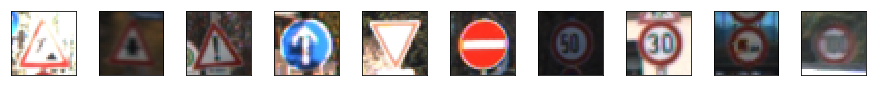

```
Rotation sample of images:
```

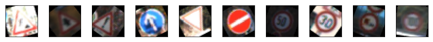

```
Noise sample of images:
```

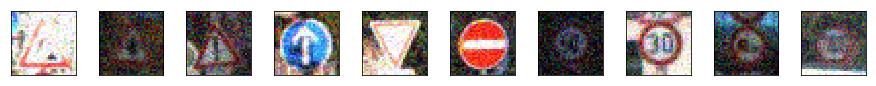

```
Horizontal flip sample of images:
```

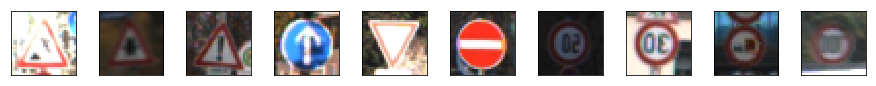

```
Blur sample of images:
```

[figure not shown]

```python
display_image()
```

Combining all these agumentaions together, I create the ImageAugmentation class so that with a random probability, some images are left as original while other images can be transformed with one of the four augmentation methods discussed above. I experimented with a greater extent of augmentation methods and it did not turn out well. I suspect this is because the original images are not of good quality and the size of images are only 32 by 32 that a greater degree augmentation may distort this small extent of the existing information heavily.

```python
class ImageAugmentation:
    def __init__(self, bs):
        self.bs = bs

    def augmentation(self, X, y):
        if len(X)!=0:
            X_augmented = []
            for i in range(len(X)):
                rand_prob = random.random()
                X_copy = X[i]
                if rand_prob > 0.4:
                    pass
                else:
                    rand_transform = random.randrange(4)
                    if rand_transform==0:
                        X_copy = self.rotate(X_copy, 50)
                    if rand_transform==1:
                        X_copy = self.add_noise(X_copy)
                    if rand_transform==2:
                        if y[i] not in [33, 34, 36, 37, 38, 39]:
                            X_copy = self.flip_horizontal(X_copy)
                    if rand_transform==3:
                        X_copy = self.blur(X_copy)
                X_augmented.append(X_copy)
        return X_augmented, y

    def rotate(self, X, degree):
        random_degree = random.uniform(-1*degree, degree)
        image = sk.transform.rotate(X, random_degree)
        return image

    def add_noise(self, X):
        image = sk.util.random_noise(X, mode='gaussian')
        return image

    def flip_horizontal(self, X):
        image = X[:, ::-1]
        return image

    def blur(self, X):
        random_int = random.randrange(4)
        image = sk.filters.gaussian(X, random_int, multichannel=True, mode='reflect')
        return image
```

Data preparation is done. It is time to think about what architecutre I would use for classifying the transformed dataset!

## Model Architecture

The model for classifying traffic signs incorporstes Resnet-like and SE-like blocks within the architecture. The characteristics of the architecture is as follow:

1. There are four resnet blocks and three SE blocks.
2. Input data is filtered through one convolutional layer first.
3. Each resnet block has two convolutional layer, batch normalisation layer, and relu activation. At the end of each resnet block, identify conv layer and the output of two resnet blocks are added.
4. Following every resnet block except for the last resnet block, SE block contians average pooling, convolutional layer, relu activation, convolutional layer, relu, sigmoid and concatenation of the previous output and the output from the resnet block. Finally, the output of this concatenation is combined together with the identity conv layer.

The overarching model architecture is described in a diagram below.

[figure not shown]

```python
def ResNet_SE_like(x):
    mu = 0
    sigma = 0.1
    #reduction rate for SE blocks
    reduction = 16
    #weight initialiser and regularizer (l2) for conv layers in SE blocks
    weight_init = tf.contrib.layers.variance_scaling_initializer()
    weight_regularizer = tf.contrib.layers.l2_regularizer(1e-04)

    #new_height = (input_height - filter_height + 2 * P)/S + 1
    #new_width = (input_width - filter_width + 2 * P)/S + 1

    #resnet block 1_0 - conv, batch norm, relu - 16 channels
    with tf.variable_scope('weight10', reuse=tf.AUTO_REUSE):
        conv1_W0 = tf.get_variable("weight10", shape=(3, 3, 3, 16), initializer=tf.contrib.layers.xavier_initializer())
    with tf.variable_scope('bias10', reuse=tf.AUTO_REUSE):
        conv1_b0 = tf.get_variable("bias10", shape=(16), initializer=tf.contrib.layers.xavier_initializer())
    conv1   = tf.nn.conv2d(x, conv1_W0, strides=[1, 1, 1, 1], padding='SAME') + conv1_b0

    residual = conv1

    with tf.variable_scope('bn10', reuse=tf.AUTO_REUSE):
        conv1 = tf.layers.batch_normalization(conv1, momentum=0.99, epsilon=1e-03, center=True,
                                          scale=True, training=True, name='bn10')
    conv1 = tf.nn.relu(conv1)

    #resnet block 1_1 - conv, batch norm, relu - 16 channels
    with tf.variable_scope('weight11', reuse=tf.AUTO_REUSE):
        conv1_W1 = tf.get_variable("weight11", shape=(3, 3, 16, 16), initializer=tf.contrib.layers.xavier_initializer())
    with tf.variable_scope('bias11', reuse=tf.AUTO_REUSE):
        conv1_b1 = tf.get_variable("bias11", shape=(16), initializer=tf.contrib.layers.xavier_initializer())
    conv1  = tf.nn.conv2d(conv1, conv1_W1, strides=[1, 1, 1, 1], padding='SAME') + conv1_b1

    with tf.variable_scope('bn11', reuse=tf.AUTO_REUSE):
        conv1 = tf.layers.batch_normalization(conv1, momentum=0.99, epsilon=1e-03, center=True,
                                          scale=True, training=True, name='bn11')
    conv1 = conv1 + residual
    out = tf.nn.relu(conv1)

    #se block 1 - squueze to 1 channel back to 16 channel
    conv1 = tf.nn.avg_pool(out, [1, 1, 1, 1], [1, 1, 1, 1], 'SAME', data_format="NHWC")

    conv1 = tf.layers.conv2d(inputs=conv1, filters=16//reduction,
                         kernel_size=1, kernel_initializer=weight_init,
                             kernel_regularizer=weight_regularizer,
                         strides=1, use_bias=False, padding='SAME')
    conv1 = tf.nn.relu(conv1)
    conv1 = tf.layers.conv2d(inputs=conv1, filters=16,
                         kernel_size=1, kernel_initializer=weight_init,
                             kernel_regularizer=weight_regularizer,
                         strides=1, use_bias=False, padding='SAME')
    conv1 = tf.nn.relu(conv1)
    conv1 = tf.nn.sigmoid(conv1)
    conv1 = conv1*out
    conv1 = conv1+residual

    #resnet block 2_0 - 64 channels
    with tf.variable_scope('weight20', reuse=tf.AUTO_REUSE):
        conv2_W0 = tf.get_variable("weight20", shape=(3, 3, 16, 64), initializer=tf.contrib.layers.xavier_initializer())
    with tf.variable_scope('bias20', reuse=tf.AUTO_REUSE):
        conv2_b0 = tf.get_variable("bias20", shape=(64), initializer=tf.contrib.layers.xavier_initializer())
    conv2   = tf.nn.conv2d(conv1, conv2_W0, strides=[1, 1, 1, 1], padding='SAME') + conv2_b0

    residual = conv2

    with tf.variable_scope('bn20', reuse=tf.AUTO_REUSE):
        conv2 = tf.layers.batch_normalization(conv2, momentum=0.99, epsilon=1e-03, center=True,
                                          scale=True, training=True, name='bn20')
    conv2 = tf.nn.relu(conv2)

    #resnet block 2_1 - 64 channel
    with tf.variable_scope('weight21', reuse=tf.AUTO_REUSE):
        conv2_W1 = tf.get_variable("weight21", shape=(3, 3, 64, 64), initializer=tf.contrib.layers.xavier_initializer())
    with tf.variable_scope('bias21', reuse=tf.AUTO_REUSE):
        conv2_b1 = tf.get_variable("bias21", shape=(64), initializer=tf.contrib.layers.xavier_initializer())
    conv2   = tf.nn.conv2d(conv2, conv2_W1, strides=[1, 1, 1, 1], padding='SAME') + conv2_b1

    with tf.variable_scope('bn21', reuse=tf.AUTO_REUSE):
        conv2 = tf.layers.batch_normalization(conv2, momentum=0.99, epsilon=1e-03, center=True,
                                          scale=True, training=True, name='bn21')
    conv2 = conv2 + residual
    out = tf.nn.relu(conv2)

    #se block 2 - squeeze into 4 channels and back to 64 channels
    conv2 = tf.nn.avg_pool(out, [1, 1, 1, 1], [1, 1, 1, 1], 'SAME', data_format="NHWC")

    conv2 = tf.layers.conv2d(inputs=conv2, filters=64//reduction,
                         kernel_size=1, kernel_initializer=weight_init,
                             kernel_regularizer=weight_regularizer,
                         strides=1, use_bias=False, padding='SAME')
    conv2 = tf.nn.relu(conv2)
    conv2 = tf.layers.conv2d(inputs=conv2, filters=64,
                         kernel_size=1, kernel_initializer=weight_init,
                             kernel_regularizer=weight_regularizer,
                         strides=1, use_bias=False, padding='SAME')
    conv2 = tf.nn.relu(conv2)
    conv2 = tf.nn.sigmoid(conv2)
    conv2 = conv2*out
    conv2 = conv2+residual

    #resent block 3_0 - 128 channels
    with tf.variable_scope('weight30', reuse=tf.AUTO_REUSE):
        conv3_W0 = tf.get_variable("weight30", shape=(3, 3, 64, 128), initializer=tf.contrib.layers.xavier_initializer())
    with tf.variable_scope('bias30', reuse=tf.AUTO_REUSE):
        conv3_b0 = tf.get_variable("bias30", shape=(128), initializer=tf.contrib.layers.xavier_initializer())
    conv3   = tf.nn.conv2d(conv2, conv3_W0, strides=[1, 1, 1, 1], padding='SAME') + conv3_b0

    residual = conv3
    with tf.variable_scope('bn30', reuse=tf.AUTO_REUSE):
        conv3 = tf.layers.batch_normalization(conv3, momentum=0.99, epsilon=1e-03, center=True,
                                          scale=True, training=True, name='bn30')
    conv3 = tf.nn.relu(conv3)

    #resnet block 3_1 - 128 channels
    with tf.variable_scope('weight31', reuse=tf.AUTO_REUSE):
        conv3_W1 = tf.get_variable("weight31", shape=(3, 3, 128, 128), initializer=tf.contrib.layers.xavier_initializer())
    with tf.variable_scope('bias31', reuse=tf.AUTO_REUSE):
        conv3_b1 = tf.get_variable("bias31", shape=(128), initializer=tf.contrib.layers.xavier_initializer())
    conv3   = tf.nn.conv2d(conv3, conv3_W1, strides=[1, 1, 1, 1], padding='SAME') + conv3_b1

    with tf.variable_scope('bn31', reuse=tf.AUTO_REUSE):
        conv3 = tf.layers.batch_normalization(conv3, momentum=0.99, epsilon=1e-03, center=True,
                                          scale=True, training=True, name='bn31')
    conv3 = conv3 + residual
    out = tf.nn.relu(conv3)

    #se block 3 - squeeze into 8 channels and back to 128 channels
    conv3 = tf.nn.avg_pool(out, [1, 1, 1, 1], [1, 1, 1, 1], 'SAME', data_format="NHWC")

    conv3 = tf.layers.conv2d(inputs=conv3, filters=128//reduction,
                         kernel_size=1, kernel_initializer=weight_init,
                             kernel_regularizer=weight_regularizer,
                         strides=1, use_bias=False, padding='SAME')
    conv3 = tf.nn.relu(conv3)
    conv3 = tf.layers.conv2d(inputs=conv3, filters=128,
                         kernel_size=1, kernel_initializer=weight_init,
                             kernel_regularizer=weight_regularizer,
                         strides=1, use_bias=False, padding='SAME')
    conv3 = tf.nn.relu(conv3)
    conv3 = tf.nn.sigmoid(conv3)
    conv3 = conv3*out
    conv3 = conv3+residual

    #resnet block 4_0 - 256 channels
    with tf.variable_scope('weight40', reuse=tf.AUTO_REUSE):
        conv4_W0 = tf.get_variable("weight40", shape=(3, 3, 128, 256), initializer=tf.contrib.layers.xavier_initializer())
    with tf.variable_scope('bias40', reuse=tf.AUTO_REUSE):
        conv4_b0 = tf.get_variable("bias40", shape=(256), initializer=tf.contrib.layers.xavier_initializer())
    conv4   = tf.nn.conv2d(conv3, conv4_W0, strides=[1, 1, 1, 1], padding='SAME') + conv4_b0

    residual = conv4
    with tf.variable_scope('bn40', reuse=tf.AUTO_REUSE):
        conv4 = tf.layers.batch_normalization(conv4, momentum=0.99, epsilon=1e-03, center=True,
                                          scale=True, training=True, name='bn40')
    conv4 = tf.nn.relu(conv4)

    #resnet block 4_1 - 256 channels
    with tf.variable_scope('weight41', reuse=tf.AUTO_REUSE):
        conv4_W1 = tf.get_variable("weight41", shape=(3, 3, 256, 256), initializer=tf.contrib.layers.xavier_initializer())
    with tf.variable_scope('bias41', reuse=tf.AUTO_REUSE):
        conv4_b1 = tf.get_variable("bias41", shape=(256), initializer=tf.contrib.layers.xavier_initializer())
    conv4   = tf.nn.conv2d(conv4, conv4_W1, strides=[1, 1, 1, 1], padding='SAME') + conv4_b1

    with tf.variable_scope('bn41', reuse=tf.AUTO_REUSE):
        conv4 = tf.layers.batch_normalization(conv4, momentum=0.99, epsilon=1e-03, center=True,
                                          scale=True, training=True, name='bn41')
    conv4 = conv4 + residual
    conv4 = tf.nn.relu(conv4)


    #global average pooling for fully-connected layer - pooling across 32x32
    conv4 = tf.reduce_mean(conv4, axis=[1, 2])

    #flatten the tensor
    fc0   = flatten(conv4)

    #first fully-connected layer
    shape_flatten = int(fc0.shape[1])
    with tf.variable_scope('fc1w', reuse=tf.AUTO_REUSE):
        fc1_W = tf.Variable(tf.truncated_normal(shape=(shape_flatten, 120), mean = mu, stddev = sigma, name="fc1w"))
    with tf.variable_scope('fc1b', reuse=tf.AUTO_REUSE):
        fc1_b = tf.Variable(tf.zeros(120), name="fc1b")
    fc1   = tf.matmul(fc0, fc1_W) + fc1_b
    fc1    = tf.nn.relu(fc1)

    #second fully-connected layer
    with tf.variable_scope('fc2w', reuse=tf.AUTO_REUSE):
        fc2_W  = tf.Variable(tf.truncated_normal(shape=(120, 84), mean = mu, stddev = sigma, name="fc2w"))
    with tf.variable_scope('fc2b', reuse=tf.AUTO_REUSE):
        fc2_b  = tf.Variable(tf.zeros(84), name="fc2b")
    fc2    = tf.matmul(fc1, fc2_W) + fc2_b
    fc2    = tf.nn.relu(fc2)

    #third fully-connectd layer with the number of classes output
    with tf.variable_scope('fc3w', reuse=tf.AUTO_REUSE):
        fc3_W  = tf.Variable(tf.truncated_normal(shape=(84, 43), mean = mu, stddev = sigma, name="fc3w"))
    with tf.variable_scope('fc3b', reuse=tf.AUTO_REUSE):
        fc3_b  = tf.Variable(tf.zeros(43), name="fc3b")
    logits = tf.matmul(fc2, fc3_W) + fc3_b

    return logits
```

The following reference github projects were helpful in creating this model.

- https://github.com/taki0112/ResNet-Tensorflow
- https://github.com/Cadene/pretrained-models.pytorch/blob/master/pretrainedmodels/models/senet.py

I intentionally included three SE blocks instead of four because the accuracy was better with the three blocks.

Now we have the data and the model architecture prepared, it is time to create a pipeline function and train the model.

## Training Pipeline

To train on the dataset, a number of hyperparameters had to be decided. These includes epoch, batch size, learning rate, loss function, optimiser and metric:

```python
class TrainPipeline:
    def __init__(self, epoch, bs, X_train, y_train, X_valid, y_valid, X_test, y_test, num_classes):
        self.epoch = epoch
        self.bs = bs
        self.X_train = X_train
        self.y_train_set = y_train
        self.X_valid = X_valid
        self.y_valid_set = y_valid
        self.X_test = X_test
        self.y_test = y_test
        self.n_classes = num_classes

    def initialise_input(self, num_classes):
        self.x = tf.placeholder(tf.float32, (None, 32, 32, 3))
        self.y = tf.placeholder(tf.int32, (None))
        self.one_hot_y = tf.one_hot(self.y, num_classes)
        self.learning_rate = tf.placeholder(tf.float32, shape=[])

    def create_model(self):
        self.logits = ResNet_SE_like(self.x)

    def define_lossf(self):
        self.cross_entropy = tf.nn.softmax_cross_entropy_with_logits(labels=self.one_hot_y, logits=self.logits)
        self.loss_operation = tf.reduce_mean(self.cross_entropy)
        self.optimizer = tf.train.AdamOptimizer(learning_rate = self.learning_rate).minimize(self.loss_operation)

    def define_metric(self):
        self.correct_prediction = tf.equal(tf.argmax(self.logits, 1), tf.argmax(self.one_hot_y, 1))
        self.accuracy_operation = tf.reduce_mean(tf.cast(self.correct_prediction, tf.float32))
        self.saver = tf.train.Saver()

    def evaluate(self, X_data, y_data):
        num_examples = len(X_data)
        total_accuracy = 0
        sess = tf.get_default_session()
        for offset in range(0, num_examples, self.bs):
            batch_x, batch_y = X_data[offset:offset+self.bs], y_data[offset:offset+self.bs]
            accuracy = sess.run(self.accuracy_operation, feed_dict={self.x: batch_x, self.y: batch_y})
            total_accuracy += (accuracy * len(batch_x))
        return total_accuracy / num_examples

    def prep_train(self):
        self.initialise_input(self.n_classes)
        self.create_model()
        self.define_lossf()
        self.define_metric()

    def train(self, learning_rate):
        self.prep_train()
        aug = ImageAugmentation(self.bs)
        with tf.Session() as sess:
            sess.run(tf.global_variables_initializer())
            #number of cross validation data sets - 2
            num_cross = len(self.X_train)
            #number of examples in each train data set
            num_examples = len(self.X_train[0])
            for i in range(num_cross):
                print("Training cross validation {}".format(str(i)))
                print()
                X_train_c, y_train_c = shuffle(self.X_train[i], self.y_train_set[i])
                lr = learning_rate
                lr /= np.power(2, i)
                #learning rate decay and epoch reduction
                if i==0:
                    epoch = self.epoch//5 + 9
                elif i==1:
                    epoch = 7
                else:
                    epoch = self.epoch//10

                print("Learning rate: {}".format(str(lr)))

                for j in range(epoch):
                    total_accuracy = 0
                    #feed images with batch size, in this case 256 images each time
                    for offset in range(0, num_examples, self.bs):
                        end = offset + self.bs
                        batch_x, batch_y = X_train_c[offset:end], y_train_c[offset:end]
                        batch_x, batch_y = aug.augmentation(batch_x, batch_y)
                        sess.run(self.optimizer, feed_dict={self.x: batch_x, self.y: batch_y, self.learning_rate: lr})
                        #calculate training accuracy
                        accuracy = sess.run(self.accuracy_operation, feed_dict={self.x: batch_x, self.y: batch_y})
                        total_accuracy += (accuracy * len(batch_x))

                    #calculate validation accuracy
                    validation_accuracy = self.evaluate(self.X_valid[i], self.y_valid_set[i])
                    print("EPOCH {} ...".format(j+1))
                    print("Train Accuracy = {:.3f}".format(total_accuracy/num_examples))
                    print("Validation Accuracy = {:.3f}".format(validation_accuracy))
                    print()

                #after each training on cross validation data set, save the weights separately
                self.saver.save(sess, f"./model_cross{str(i)}_set")
                print(f"Model cross validation {str(i)} saved")
            test_accuracy = self.evaluate(self.X_test, self.y_test)
            print("Test Accuracy = {:.3f}".format(test_accuracy))
```

```python
learn = TrainPipeline(50, 256, X_train, y_train_set, X_valid, y_valid_set, X_test, y_test, n_classes)
```

```python
#0.974
learn.train(0.01)
```

[output not shown]

[output cut: 215 more lines]

With this training pipeline, Training accuracy is up to **98.2%** while Validation accuracy is around **99.5%**. Test accuracy turns out to be lower than the train and validation accuracy, being around **97.4%**.

## Result analysis on new data

In this section, I will test the trained model on a new dataset collected from google image search. 7 new images with different classes have been collected and tested.

To generate images consistent with the train set used previously, the downloaded images are resized to 32 x 32 and normalised.

```python
def resize_image(path_to_image, filename):
    test_img_path = os.path.join(test_data_path, filename)

    test_img = cv2.imread(test_img_path)
    test_img = cv2.cvtColor(test_img,cv2.COLOR_BGR2RGB)
    test_img = cv2.resize(test_img, (32, 32))

    return test_img
```

```python
def normalise_image(test_img):
    test_img = np.expand_dims(test_img, axis=0)
    test_img = normalise(test_img)

    return test_img
```

```python
def visualise_new_images(path_to_image):
    f = plt.figure(figsize = (15, 1))
    plt.subplots_adjust(left=0., right=1, top=0.9, bottom=0.)

    images = []
    print("Resized new images: ")
    for file_name in os.listdir(path_to_image):
        img = resize_image(path_to_image, file_name)
        images.append(img)

    for i in range(7):
        ax = f.add_subplot(1, 7, i+1, xticks=[], yticks=[])
        ax.imshow(images[i])
    plt.show()
```

```python
test_data_path = "new_images"
```

```
Resized new images:
```

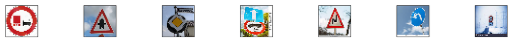

```python
visualise_new_images(test_data_path)
```

These images are located under the "new_images" folder. After resizing images, some of the new images are not really clear to even my eyes, but we will see how the model performs on these images. In particular, a classification of the fourth and last images is of interest because these images are ambiguous or blur to an extent that I would classify them with difficulties.

### Correctly classified images

Here are some images that were predicted correctly. The top five softmax scores are listed below.

```python
tf.reset_default_graph()
```

```python
x = tf.placeholder(tf.float32, (1, 32, 32, 3))

pred = tf.nn.softmax(ResNet_SE_like(x))
top_k_op = tf.nn.top_k(pred, k=5)
```

[output not shown]

[output cut: 17 more lines]

```
No passing for vehicles over 3.5 metric tons
```

[figure not shown]

```python
test_image = resize_image(test_data_path, '10.jpg')
print(class_df['SignName'].iloc[10])
plt.imshow(test_image)
test_image = normalise_image(test_image)
```

```python
with tf.Session() as sess:
    sess.run(tf.global_variables_initializer())
    saver = tf.train.import_meta_graph('model_cross4_set.meta')
    saver.restore(sess, tf.train.latest_checkpoint('.'))
    preds = sess.run(top_k_op, feed_dict={x: test_image})
```

```
INFO:tensorflow:Restoring parameters from .\model_cross4_set
```

```python
preds
```

```
TopKV2(values=array([[1.0000000e+00, 1.2504015e-08, 6.3594410e-09, 9.6721031e-10,
        2.7459071e-10]], dtype=float32), indices=array([[10, 14,  5, 12, 17]]))
```

The highest probaility is the index 10, which is No passing for vehicles over 3.5 metric tons. The model is quite certain about this sign being No passing for vehicles over 3.5 metric tons.

```
Right-of-way at the next intersection
```

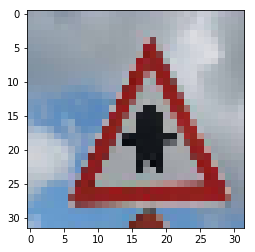

```python
test_image = resize_image(test_data_path, '11.jpg')
print(class_df['SignName'].iloc[11])
plt.imshow(test_image)
test_image = normalise_image(test_image)
```

```python
with tf.Session() as sess:
    sess.run(tf.global_variables_initializer())
    saver = tf.train.import_meta_graph('model_cross4_set.meta')
    saver.restore(sess, tf.train.latest_checkpoint('.'))
    preds = sess.run(top_k_op, feed_dict={x: test_image})
```

```
INFO:tensorflow:Restoring parameters from .\model_cross4_set
```

```python
preds
```

```
TopKV2(values=array([[9.9998546e-01, 8.0481104e-06, 6.5087875e-06, 5.1606359e-09,
        1.6530034e-09]], dtype=float32), indices=array([[11, 27, 30, 25, 28]]))
```

Again, the model classifies this sign correctly, which is Right-of-wa at the next intersection. With 99.99% confidence, the model classifies this sign correctly.

```
Priority road
```

[figure not shown]

```python
test_image = resize_image(test_data_path, '12.jpg')
print(class_df['SignName'].iloc[12])
plt.imshow(test_image)
test_image = normalise_image(test_image)
```

```python
with tf.Session() as sess:
    sess.run(tf.global_variables_initializer())
    saver = tf.train.import_meta_graph('model_cross4_set.meta')
    saver.restore(sess, tf.train.latest_checkpoint('.'))
    preds = sess.run(top_k_op, feed_dict={x: test_image})
```

```
INFO:tensorflow:Restoring parameters from .\model_cross4_set
```

```python
preds
```

```
TopKV2(values=array([[1.0000000e+00, 3.7115679e-08, 4.1040979e-10, 1.0245295e-10,
        3.2292283e-11]], dtype=float32), indices=array([[12, 17, 13, 10, 14]]))
```

This is a correct classification - Priority road. Since there are not many signs with a yellow colour in the middle of the sign, I think this sign was quite easy to be predicted correctly. Again, the model is quite confident in classifying this sign as Priority road.

```
Turn left ahead
```

[figure not shown]

```python
test_image = resize_image(test_data_path, '34.jpg')
print(class_df['SignName'].iloc[34])
plt.imshow(test_image)
test_image = normalise_image(test_image)
```

```python
with tf.Session() as sess:
    sess.run(tf.global_variables_initializer())
    saver = tf.train.import_meta_graph('model_cross4_set.meta')
    saver.restore(sess, tf.train.latest_checkpoint('.'))
    preds = sess.run(top_k_op, feed_dict={x: test_image})
```

```
INFO:tensorflow:Restoring parameters from .\model_cross4_set
```

```python
preds
```

```
TopKV2(values=array([[9.5410883e-01, 2.8740568e-02, 1.4642947e-02, 2.1260884e-03,
        2.3948622e-04]], dtype=float32), indices=array([[34, 38, 40, 36, 35]]))
```

The model classifies this sign as Turn left ahead correctly with 95.41% confidence.

Relatively clear images are classified correctly by the model.

### Incorrectly classified images

Here are the images that were classified incorrectly.

```
No passing
```

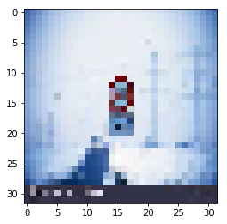

```python
test_image = resize_image(test_data_path, '9.jpg')
print(class_df['SignName'].iloc[9])
plt.imshow(test_image)
test_image = normalise_image(test_image)
```

```python
with tf.Session() as sess:
    sess.run(tf.global_variables_initializer())
    saver = tf.train.import_meta_graph('model_cross4_set.meta')
    saver.restore(sess, tf.train.latest_checkpoint('.'))
    preds = sess.run(top_k_op, feed_dict={x: test_image})
```

```
INFO:tensorflow:Restoring parameters from .\model_cross4_set
```

```python
preds
```

```
TopKV2(values=array([[0.65857655, 0.2755526 , 0.04194018, 0.01890288, 0.00149474]],
      dtype=float32), indices=array([[37, 36, 11, 34, 40]]))
```

This image is incorrectly classified because it is difficult to classify even with my eyes. The correct lable is not even within the top 5 predictions. The model classifies this sign as Go straight or left with 65.86% confidence.

```
Vehicles over 3.5 metric tons prohibited
```

[figure not shown]

```python
test_image = resize_image(test_data_path, '16.jpg')
print(class_df['SignName'].iloc[16])
plt.imshow(test_image)
test_image = normalise_image(test_image)
```

```python
with tf.Session() as sess:
    sess.run(tf.global_variables_initializer())
    saver = tf.train.import_meta_graph('model_cross4_set.meta')
    saver.restore(sess, tf.train.latest_checkpoint('.'))
    preds = sess.run(top_k_op, feed_dict={x: test_image})
```

```
INFO:tensorflow:Restoring parameters from .\model_cross4_set
```

```python
preds
```

```
TopKV2(values=array([[9.9538773e-01, 2.1716158e-03, 2.1633888e-03, 2.5331214e-04,
        1.7490192e-05]], dtype=float32), indices=array([[40, 33, 36, 38, 35]]))
```

This image is tricky one because it has two signs in one image. I thought the sign will be classified as either Vehicles over 3.5 metric tons prohibited or Ahead only. However, the classifier thinks neither; instead, it thinks the sign is about Roundabout mandatory with a high confidence of 99.54%. Again, the actual class is not within the top five predictions.

```
Double curve
```

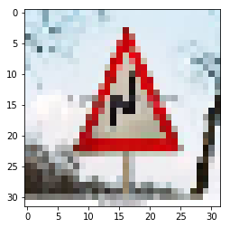

```python
test_image = resize_image(test_data_path, '21.jpg')
print(class_df['SignName'].iloc[21])
plt.imshow(test_image)
test_image = normalise_image(test_image)
```

```python
with tf.Session() as sess:
    sess.run(tf.global_variables_initializer())
    saver = tf.train.import_meta_graph('model_cross4_set.meta')
    saver.restore(sess, tf.train.latest_checkpoint('.'))
    preds = sess.run(top_k_op, feed_dict={x: test_image})
```

```
INFO:tensorflow:Restoring parameters from .\model_cross4_set
```

```python
preds
```

```
TopKV2(values=array([[0.41351804, 0.2337906 , 0.12488491, 0.08226667, 0.05781733]],
      dtype=float32), indices=array([[25, 18, 23, 10, 14]]))
```

Interestingly, the model is very unsure about what this sign is. The highest confidence is 41.35% in classifying the sign as Road work. The actual label is not predicted within the top five classes. I think this image is relatively clear to be Double curve, however, the model finds it difficult to classify.

The overall accuracy is 4/7 or 57.14%. Compared to 97.4% accuracy on the provided dataset, this accuracy seems to be low. In particular, where a confusing situation or an extreme blur exists, the model seems to make incorrect predictions. This indicates the extent of difficulties involved in setting up a wide range of components for Self Driving Cars, attempting to account for ambiguous scenes and unclear lanes.